# 7 Análisis preliminar

Autor/a

Iraitz Montalbán

Partimos de nuestros datos ya cargados, y deberemos ver la estructura base de nuestro dataframe. La función `describe` nos ofrece una primera revisión de los datos indicando nombre de las columnas, estadísticas de la distribución de datos, valores faltantes y tipo de dato.

```julia
using CSV, DataFrames

df = CSV.read(joinpath(data_path,"titanic.csv"), DataFrame)
describe(df)
```

12×7 DataFrame

| Row | variable Symbol | mean Union… | min Any | median Union… | max Any | nmissing Int64 | eltype Type |
| --- | --- | --- | --- | --- | --- | --- | --- |
| 1 | PassengerId | 446.0 | 1 | 446.0 | 891 | 0 | Int64 |
| 2 | Survived | 0.383838 | 0 | 0.0 | 1 | 0 | Int64 |
| 3 | Pclass | 2.30864 | 1 | 3.0 | 3 | 0 | Int64 |
| 4 | Name |  | Abbing, Mr. Anthony |  | van Melkebeke, Mr. Philemon | 0 | String |
| 5 | Sex |  | female |  | male | 0 | String7 |
| 6 | Age | 29.6991 | 0.42 | 28.0 | 80.0 | 177 | Union{Missing, Float64} |
| 7 | SibSp | 0.523008 | 0 | 0.0 | 8 | 0 | Int64 |
| 8 | Parch | 0.381594 | 0 | 0.0 | 6 | 0 | Int64 |
| 9 | Ticket |  | 110152 |  | WE/P 5735 | 0 | String31 |
| 10 | Fare | 32.2042 | 0.0 | 14.4542 | 512.329 | 0 | Float64 |
| 11 | Cabin |  | A10 |  | T | 687 | Union{Missing, String15} |
| 12 | Embarked |  | C |  | S | 2 | Union{Missing, String1} |

A esto podemos unirle conocer el tamaño de nuestro conjunto mediante el método `size`.

```julia
size(df)
```

```
(891, 12)
```

Deberemos entender la naturaleza de los datos que nos muestran y conocer, entre otras cuestiones:

- Si son valores numéricos, que fenómeno representan y cómo se distribuyen
- Si son valores categóricos, si las categorías vienen bien informadas y si muestran algún orden.

Esto nos obliga a explorar si son variables categóricas codificadas con números, si existen campos con una **granularidad** alta o con valor constante. Podemos pedir estadísticas concretas al método describe.

```julia
describe(df, :nunique)
```

12×2 DataFrame

| Row | variable Symbol | nunique Union… |
| --- | --- | --- |
| 1 | PassengerId |  |
| 2 | Survived |  |
| 3 | Pclass |  |
| 4 | Name | 891 |
| 5 | Sex | 2 |
| 6 | Age |  |
| 7 | SibSp |  |
| 8 | Parch |  |
| 9 | Ticket | 681 |
| 10 | Fare |  |
| 11 | Cabin | 147 |
| 12 | Embarked | 3 |

## 7.1 Selección de campos

Podemos por tanto descartar aquellos casos donde el grano de detalle es prácticamente individual.

```julia
campos_a_descartar = [:Ticket, :Name]
```

```
2-element Vector{Symbol}:
 :Ticket
 :Name
```

Vemos que únicamente ha contemplado los casos donde nos encontramos con tipos `String`. Pero sabemos, por ejemplo, que la columna *Survived* es una condición booleana de si sobrevivieron o no. Emplearemos la propia función de conversión de cada tipo, añadiéndole un `.` al final que denote *por fila*. En Julia, el punto (`.`) al final de una función o nombre de tipo (como `string.`) indica **broadcasting**, lo que aplicar una función elemento por elemento a lo largo de un array o colección, sin necesidad de escribir un bucle explícito.

Al igual que antes, empleamos el indicador `!` ya que vamos a modificar la columna en su sitio. En Julia:

- `df[:, :Columna]` devuelve una **copia** de la columna. Si modificas el resultado, el DataFrame original no cambia.
- `df[!, :Columna]` devuelve una **referencia** a la columna original. Si modificas el resultado, el DataFrame original sí cambia.

```julia
df[!,:Survived] = Bool.(df[!,:Survived])
df[!,:PassengerId] = string.(df[!,:PassengerId])
df[!,:Pclass] = string.(df[!,:Pclass]);
```

**Nota**

El carácter final `;` es simplemente para que no imprima el resultado por pantalla cuando se emplean Notebooks o documentos de Quarto `.qmd`.

Gracias a la librería `Query.jl` podemos emplear una sintaxis más compacta en nuestras consultas, añadiendo etapas de transformación como en los pipelines habituales en R o Python.

```julia
Pkg.add("Query")
```

```julia
using DataFrames, Query

campos = [:Survived, :PassengerId, :Pclass]

filas = nrow(df)

for col in campos
    únicos = df |>
        @select({Symbol(col) = _.col}) |> collect |> x -> unique(df[!, col])
    println("Columna $col tiene $(length(únicos)) valores únicos en $(filas) filas.")
    println()
end
```

```
Columna Survived tiene 2 valores únicos en 891 filas.

Columna PassengerId tiene 891 valores únicos en 891 filas.

Columna Pclass tiene 3 valores únicos en 891 filas.
```

Tenemos varios puntos en el código anterior:

- `@select` es una macro para seleccionar columnas de un DataFrame. `{Symbol(col) = _.col}` crea un diccionario o mapeo donde la clave es el símbolo de la variable col y el valor es la columna correspondiente en el DataFrame. `Symbol(col)`en sí convierte el nombre de la columna (probablemente un string) en un símbolo, que es un tipo de dato común en Julia para referirse a nombres de columnas.
- `|>` es el operador “pipe” en Julia, que pasa el resultado de la expresión anterior como argumento a la función siguiente.
- `collect` toma un iterable (como el resultado de (**select?**)) y lo convierte en una colección concreta, como un array.
- `x -> unique(df[!, col])` es una función anónima (sin nombre designado como en el caso de las lambda) que toma `x` (aunque aquí no se usa directamente) y devuelve los valores únicos de la columna col del DataFrame df.

Hemos dado un salto en este bloque así que tomaros tiempo para entender cada parte. De aquí concluimos que la columna PassengerId no será muy relevante en el análisis estadístico ya que muestra un grano muy fino de valores que únicamente permiten identificar a cada individuo de nuestro conjunto. Pasará algo muy similar con valores de texto que indiquen nombre o ticket. Este dato ya lo obtuvimos anteriormente con lo que podemos determinar que las columnas de interés en adelante serán

```julia
append!(campos_a_descartar, [:PassengerId])
select!(df, Not(campos_a_descartar));
```

Recordad que `!` modifica el dato objeto

```julia
first(df, 5)
```

5×9 DataFrame

| Row | Survived Bool | Pclass String | Sex String7 | Age Float64? | SibSp Int64 | Parch Int64 | Fare Float64 | Cabin String15? | Embarked String1? |
| --- | --- | --- | --- | --- | --- | --- | --- | --- | --- |
| 1 | false | 3 | male | 22.0 | 1 | 0 | 7.25 | missing | S |
| 2 | true | 1 | female | 38.0 | 1 | 0 | 71.2833 | C85 | C |
| 3 | true | 3 | female | 26.0 | 0 | 0 | 7.925 | missing | S |
| 4 | true | 1 | female | 35.0 | 1 | 0 | 53.1 | C123 | S |
| 5 | false | 3 | male | 35.0 | 0 | 0 | 8.05 | missing | S |

**TipFrameworks de manipulación**

Tenéis más información en [DataFrames.jl > Querying frameworks](https://dataframes.juliadata.org/stable/man/querying_frameworks/)

## 7.2 Valores numéricos

Una de las mejores formas de conocer las distribuciones de datos es precisamente visualizando su histograma o gráfico de densidad. Deberéis instalar los paquetes de visualización pertinentes.

```julia
Pkg.add("StatsPlots")
```

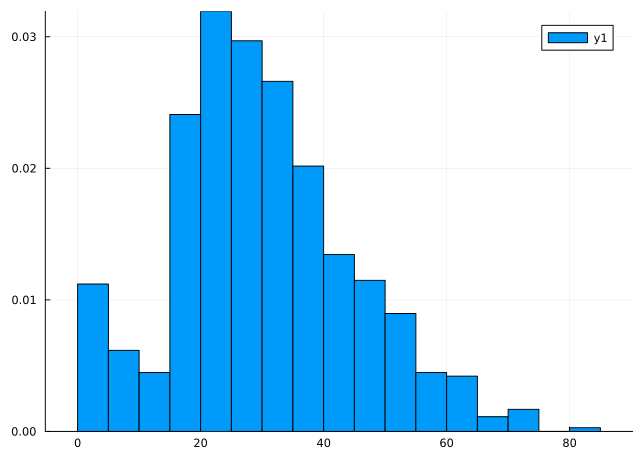

```julia
using StatsPlots

histogram(df.Age, normalize=true)
```

Vemos que si lo comparamos con una distribución normal, las gráficas difieren bastante. Esto obliga a evaluar la normalidad de la variable antes de dar por buena cualquier técnica que la presuponga.

**TipGráfico de distribución normal**

```julia
Pkg.add("Distributions")
```

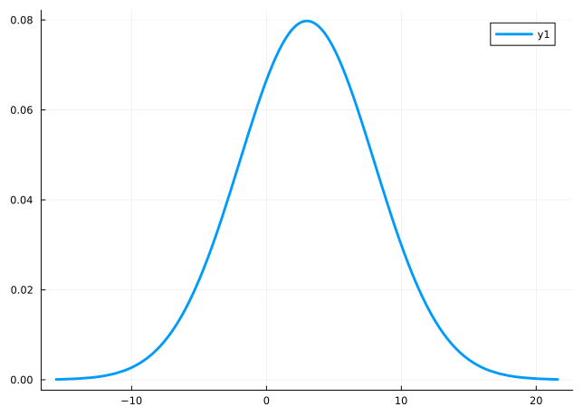

```julia
using Distributions
#| output: collapse

plot(Normal(3, 5), lw=3)
```

El primer reto al que nos enfrentaremos será el de poder mostrar el diagrama de densidad, ya que no permite la existencia de valores faltantes. Y como podemos ver existen varios para la columna age. Deberemos aprender a filtrar en base a una condición.

### 7.2.1 Valores faltantes

En el caso de Julia `missing` es un valor especial que representa un dato ausente en una celda.

```julia
typeof(missing)
```

```
Missing
```

Existen funciones específicas para eliminar o simplemente filtrar (`filter`) en base a la condición de dato faltante (`ismissing`). En este caso podremos ver los primeros tres elementos en nuestro dataframe donde se cumple la condición de dato faltante en el campo edad (`:Age`).

```julia
first(
    filter(
        :Age => ismissing, df
    ),
    3 # mostramos los primeros tres elementos
)
```

3×9 DataFrame

| Row | Survived Bool | Pclass String | Sex String7 | Age Float64? | SibSp Int64 | Parch Int64 | Fare Float64 | Cabin String15? | Embarked String1? |
| --- | --- | --- | --- | --- | --- | --- | --- | --- | --- |
| 1 | false | 3 | male | missing | 0 | 0 | 8.4583 | missing | Q |
| 2 | true | 2 | male | missing | 0 | 0 | 13.0 | missing | S |
| 3 | true | 3 | female | missing | 0 | 0 | 7.225 | missing | C |

Y así podemos ver la densidad indicando nuestro dataframe modificado para que no cumpla esta condición. `StatsPlots` nos da la opción de explorar otras macros (ya vimos la macro de `@time`) que en este caso será el turno de `@df`. Esta macro, empleada con la sintaxis

```julia
@df <tabla> <función de visualización>
```

nos permite definir una estructura tabular que luego será empleada en la función de visualización a la que solo deberemos indicarle en qué columnas centrarse.

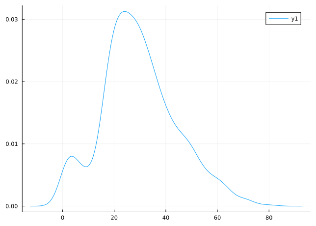

```julia
@df filter(:Age => !ismissing, df) density(:Age)
```

Como vemos, la función de densidad nos presenta un perímetro continuo sobre el histograma anterior. Podemos evaluar la normalidad de nuestra columna empleando tests estadísticos. La librería `HypothesisTests.jl` nos dará buenas referencias de [cuales](https://juliastats.org/HypothesisTests.jl/stable/) podemos usar.

Por simplificar de momento, viendo que la media y la mediana muestra valores parejos para el intervalo de datos, asumiremos dicha normalidad y veremos como imputar la media como valor estimado a los datos faltantes de nuestro dataframe.

```julia
using Statistics

mean(skipmissing(df.Age))
```

```
29.69911764705882
```

Este valor lo reemplazaremos indicando que queremos transformar (alterando el objeto `df`)

```julia
# Calculamos la media UNA sola vez. Si la dejamos dentro de `ByRow`, Julia la
# recalcula para cada fila y la operación pasa a ser O(n²).
media_edad = mean(skipmissing(df.Age))

transform!(df, :Age => ByRow(x -> coalesce(x, media_edad)); renamecols=false)
describe(df)
```

9×7 DataFrame

| Row | variable Symbol | mean Union… | min Any | median Union… | max Any | nmissing Int64 | eltype Type |
| --- | --- | --- | --- | --- | --- | --- | --- |
| 1 | Survived | 0.383838 | false | 0.0 | true | 0 | Bool |
| 2 | Pclass |  | 1 |  | 3 | 0 | String |
| 3 | Sex |  | female |  | male | 0 | String7 |
| 4 | Age | 29.6991 | 0.42 | 29.6991 | 80.0 | 0 | Float64 |
| 5 | SibSp | 0.523008 | 0 | 0.0 | 8 | 0 | Int64 |
| 6 | Parch | 0.381594 | 0 | 0.0 | 6 | 0 | Int64 |
| 7 | Fare | 32.2042 | 0.0 | 14.4542 | 512.329 | 0 | Float64 |
| 8 | Cabin |  | A10 |  | T | 687 | Union{Missing, String15} |
| 9 | Embarked |  | C |  | S | 2 | Union{Missing, String1} |

**AdvertenciaCuidado con imputar antes de tiempo**

Estamos calculando la media sobre **todo** el conjunto. Es válido para explorar, pero en cuanto entremos en modelado habrá que hacerlo *después* de separar entrenamiento y test y usando solo el primero. Si no, la información del conjunto de test se filtra en el entrenamiento y las métricas salen optimistas.

Tras esto, con las dos columnas restantes podemos optar por eliminar estos datos. `dropmissing` eliminará las filas que contengan valores faltantes en sus celdas.

```julia
df_sinfilas = dropmissing(df)
size(df_sinfilas)
```

```
(202, 9)
```

O mediante la función `select` podemos indicarle que no queremos las columnas con datos faltantes. Para esta macro deberemos usar otro paquete muy habitual para este tipo de labores.

```julia
Pkg.add("DataFramesMeta")
```

```julia
using DataFramesMeta

select!(df, Not(:Cabin, :Embarked))
describe(df)
```

7×7 DataFrame

| Row | variable Symbol | mean Union… | min Any | median Union… | max Any | nmissing Int64 | eltype DataType |
| --- | --- | --- | --- | --- | --- | --- | --- |
| 1 | Survived | 0.383838 | false | 0.0 | true | 0 | Bool |
| 2 | Pclass |  | 1 |  | 3 | 0 | String |
| 3 | Sex |  | female |  | male | 0 | String7 |
| 4 | Age | 29.6991 | 0.42 | 29.6991 | 80.0 | 0 | Float64 |
| 5 | SibSp | 0.523008 | 0 | 0.0 | 8 | 0 | Int64 |
| 6 | Parch | 0.381594 | 0 | 0.0 | 6 | 0 | Int64 |
| 7 | Fare | 32.2042 | 0.0 | 14.4542 | 512.329 | 0 | Float64 |

## 7.3 Variables categóricas

Las variables categóricas son un tipo especial de variable que se utiliza para representar datos que pueden tomar un número limitado de valores distintos, llamados categorías o niveles.

En Julia, las variables categóricas se manejan principalmente usando el paquete `CategoricalArrays.jl`. Este paquete proporciona el tipo `CategoricalArray`, que permite almacenar datos categóricos de manera eficiente y realizar operaciones como ordenamiento, agrupamiento y comparación entre categorías.

En nuestro caso, la columna `Pclass` muestra categorías de prioridad de los pasajeros que encajarían dentro de la descripción de niveles.

```julia
Pkg.add("CategoricalArrays")
```

```julia
using CategoricalArrays

# Creamos una copia del dataframe
df_cat = copy(df)

# Primero, reemplazamos los valores numéricos por los nombres de nivel deseados
df_cat[!, :Pclass] = replace(df_cat[!, :Pclass], "1" => "Primera", "2" => "Segunda", "3" => "Tercera")

# Luego, convertimos la columna a categórica con los niveles y orden deseado
levels = ["Tercera", "Segunda", "Primera"]
df_cat[!, :Pclass] = categorical(df_cat[!, :Pclass]; levels, ordered=true)

# Y comprobamos el resultado
describe(df_cat)
```

7×7 DataFrame

| Row | variable Symbol | mean Union… | min Any | median Union… | max Any | nmissing Int64 | eltype DataType |
| --- | --- | --- | --- | --- | --- | --- | --- |
| 1 | Survived | 0.383838 | false | 0.0 | true | 0 | Bool |
| 2 | Pclass |  | Tercera |  | Primera | 0 | CategoricalValue{String, UInt32} |
| 3 | Sex |  | female |  | male | 0 | String7 |
| 4 | Age | 29.6991 | 0.42 | 29.6991 | 80.0 | 0 | Float64 |
| 5 | SibSp | 0.523008 | 0 | 0.0 | 8 | 0 | Int64 |
| 6 | Parch | 0.381594 | 0 | 0.0 | 6 | 0 | Int64 |
| 7 | Fare | 32.2042 | 0.0 | 14.4542 | 512.329 | 0 | Float64 |

Gracias a ser categóricas ordenadas, podemos realizar comparativas como si de números se tratara pero empleando una sintaxis que nos aporta cierta claridad semántica. Si ordenamos de forma ascendente vemos que los viajeros en **Tercera** están en una categoría inferior a los de **Primera**.

```julia
first(sort(df_cat, :Pclass), 3)
```

3×7 DataFrame

| Row | Survived Bool | Pclass Cat… | Sex String7 | Age Float64 | SibSp Int64 | Parch Int64 | Fare Float64 |
| --- | --- | --- | --- | --- | --- | --- | --- |
| 1 | false | Tercera | male | 22.0 | 1 | 0 | 7.25 |
| 2 | true | Tercera | female | 26.0 | 0 | 0 | 7.925 |
| 3 | false | Tercera | male | 35.0 | 0 | 0 | 8.05 |

```julia
last(sort(df_cat, :Pclass), 3)
```

3×7 DataFrame

| Row | Survived Bool | Pclass Cat… | Sex String7 | Age Float64 | SibSp Int64 | Parch Int64 | Fare Float64 |
| --- | --- | --- | --- | --- | --- | --- | --- |
| 1 | true | Primera | female | 56.0 | 0 | 1 | 83.1583 |
| 2 | true | Primera | female | 19.0 | 0 | 0 | 30.0 |
| 3 | true | Primera | male | 26.0 | 0 | 0 | 30.0 |

Cosa que no podríamos hacer con el uso de cadenas de texto.

```julia
"Primera" < "Tercera"
```

```
true
```

Ya tenemos un conjunto de datos algo más limpio. Ahora toca estudiarlo en profundidad. Si queremos guardarlo para más adelante podemos volcar el DataFrame a fichero aunque si lo volcamos a un CSV o fichero de texto podemos perder la información categórica. De hecho, muchos formatos y entornos no serán compatibles con esta tipología de dato concreta.

```julia
using Parquet

df[!,:Sex] = String.(df[!,:Sex]);

write_parquet(joinpath(data_path,"titanic.parquet"), df)
```

```
4
```